# How Efficient Is the Windy City? A Decade of Energy Use in Chicago’s Big Buildings

DAT 301 - Project 1 (Individual Data Science Project)

Sedona Adams

Fall 2026

# 1. Background, Motivation, and Research Questions

## 1.1 Why buildings?

When people think about climate change, they picture cars, power plants, and airplanes. In big cities like Chicago, though, the **buildings themselves** are one of the largest sources of greenhouse gas emissions. Every office tower, apartment complex, school, and hospital burns natural gas for heat and draws electricity for lights, elevators, and air conditioning. Chicago’s winters (think *Polar Vortex*, not *Cloud Gate selfie weather*) make heating especially energy hungry. If a city wants to cut emissions, it has to understand how its buildings use energy: which ones are efficient, which ones are wasteful, and whether things are improving.

To get that information, the City of Chicago passed the **Chicago Energy Benchmarking Ordinance**. Owners of large buildings (generally those over 50,000 square feet) must report their annual energy use to the city, and the city publishes the results on the Chicago Data Portal. That makes this one of the richest public datasets about how a major American city actually consumes energy.

## 1.2 Why this topic matters to me

I picked this dataset from the open data portals list (Chicago is on it) for three reasons. First, it is *real* and *messy*, with ten years of reports, many missing values, numbers stored as text with commas, and some wildly implausible entries. That is exactly the kind of data I will meet in a job. Second, it connects data science to something that matters: energy efficiency is one of the few climate levers a city can pull directly. Third, I am curious about a question that sounds simple but is not: **are buildings actually getting better, or do the statistics just make it look that way?**

## 1.3 The dataset

The data come from the **Chicago Energy Benchmarking** dataset on the City of Chicago Data Portal (data.cityofchicago.org), downloaded as `Chicago_Energy_Benchmarking_20261029.csv`. Each row is one building (or property) in one reporting year, so the same building appears many times. The file covers data years **2014 to 2023**.

The variables most important to my analysis are:

| Variable | Meaning |
| --- | --- |
| `Data Year` | The year the energy use was measured (2014-2023) |
| `ID` | A building identifier that lets me follow the same building across years |
| `Reporting Status` | Whether the owner submitted data, was exempt, or did not submit |
| `Primary Property Type` | Multifamily housing, office, school, hotel, hospital, and so on |
| `Year Built` | Construction year of the building |
| `Gross Floor Area - Buildings (sq ft)` | Size of the building |
| `Site EUI (kBtu/sq ft)` | **Energy Use Intensity**: energy used on-site per square foot per year. This is the main efficiency measure, because it adjusts for building size |
| `Weather Normalized Site EUI` | The same measure, adjusted for how hot or cold the year was |
| `Electricity`, `Natural Gas`, `District Steam Use (kBtu)` | Energy consumed by fuel type |
| `Total GHG Emissions` and `GHG Intensity (kg CO2e/sq ft)` | Greenhouse gas emissions, total and per square foot |
| `ENERGY STAR Score` and `Chicago Energy Rating` | Performance scores (1-100 and 1-4 stars) |
| `Community Area`, `Latitude`, `Longitude` | Location within Chicago |

A note on the main measure: **EUI** is “energy per square foot.” A huge building can use enormous total energy and still be efficient per square foot, while a tiny building can be wasteful. Using EUI lets me compare apples to apples.

## 1.4 Research questions

1. **Progress:** Has the energy intensity of Chicago’s large buildings really fallen since 2014? And is the improvement real, or does it come from changes in *which* buildings report, or from weather?
2. **Age:** Do older buildings use more energy per square foot than newer ones? (It sounds obvious. I suspect it is more complicated.)
3. **COVID-19:** Did the pandemic change energy use differently for different kinds of buildings, and did the change last?
4. **Emissions:** Which property types contribute the most to the city’s building emissions *relative to how many buildings they represent*? What role does the fuel mix (natural gas vs. electricity) play?

## 1.5 What I hope to learn

I expect to find that average efficiency improved, but I want to test whether that improvement is *genuine* by following the **same buildings** over time. I expect old buildings to be wasteful, but I want to see whether the data agree. I expect offices to have been hit hard by the pandemic, and I want to know whether they bounced back. Finally, I want to learn where a policymaker should focus: on many small contributors or a few giants.

# 2. Data Wrangling and Cleaning

## 2.1 Reading the file and first impressions

I read every column as text first. This is on purpose. When I opened the file, I noticed that numeric columns such as floor area and electricity use contain **commas** (for example `65,250`), so R would otherwise either misread them or treat them as text. Reading everything as text lets me control exactly how each column is converted.

```r
raw <- read_csv("Chicago_Energy_Benchmarking_20261029.csv",
                col_types = cols(.default = col_character()),
                show_col_types = FALSE)

cat("Rows:", nrow(raw), " Columns:", ncol(raw), "\n")
```

```
## Rows: 28329  Columns: 30
```

```r
glimpse(raw[, 1:12])
```

```
## Rows: 28,329
## Columns: 12
## $ `Data Year`                            <chr> "2021", "2021", "2021", "2022",…
## $ ID                                     <chr> "101671", "101826", "102323", "…
## $ `Property Name`                        <chr> NA, "Drexel Building", NA, NA, …
## $ `Reporting Status`                     <chr> "Not Submitted", "Not Submitted…
## $ Address                                <chr> "6101 6115 N SEELEY AVE", "8136…
## $ `ZIP Code`                             <chr> "60659", "60619", "60624", "606…
## $ `Chicago Energy Rating`                <chr> "0.0", "0.0", "0.0", "4.0", "0.…
## $ `Exempt From Chicago Energy Rating`    <chr> "false", "false", "false", "fal…
## $ `Community Area`                       <chr> "WEST RIDGE", "CHATHAM", "HUMBO…
## $ `Primary Property Type`                <chr> NA, NA, NA, "Office", NA, NA, N…
## $ `Gross Floor Area - Buildings (sq ft)` <chr> "65,250", "66,888", "93,000", "…
## $ `Year Built`                           <chr> NA, NA, NA, "2019", NA, NA, NA,…
```

## 2.2 Problems found and how I fixed them

| Problem found | Why it matters | What I did |
| --- | --- | --- |
| Column names are long and contain spaces and symbols (`Site EUI (kBtu/sq ft)`) | Hard to type and error prone | Renamed to short snake_case names and kept only the columns I need |
| Numbers stored as text with commas (`65,250`) | Cannot compute averages on text | Converted with `parse_number()` |
| **Reporting status labels changed between years**: 2020 and 2022 use “Submitted Data” while other years use “Submitted” | Filtering on one label would silently throw away two whole years | Merged both labels into a single `Submitted` category |
| Many rows have no data (not submitted, exempt, not covered) | Their energy columns are empty, so they would distort every summary | Kept them to study reporting, but excluded them from the efficiency analysis |
| **Community area names have inconsistent capitalization** (`NEAR WEST SIDE` and `Near West Side`) | The same neighborhood would be counted as two | Converted to upper case and trimmed whitespace |
| `Chicago Energy Rating` uses `0` for “not rated” | A 0 would look like the worst possible rating | Recoded 0 as missing |
| Extreme EUI values (some above 1,000 kBtu/sq ft, one above 15,000) | A few typos or special facilities can dominate averages and wreck every graph | Excluded EUI values at or below zero and above 500, and documented how many were removed |
| Impossible or suspicious years built | Would distort the age analysis | Set to missing if before 1800 or later than the data year |
| Negative fuel use values (credits or corrections) | Cannot compute a fuel share from a negative energy use | Treated negatives as zero when computing fuel mix |

```r
energy <- raw %>%
  rename(
    year          = `Data Year`,
    id            = ID,
    property_name = `Property Name`,
    status        = `Reporting Status`,
    chicago_rating = `Chicago Energy Rating`,
    community_area = `Community Area`,
    property_type = `Primary Property Type`,
    gfa           = `Gross Floor Area - Buildings (sq ft)`,
    year_built    = `Year Built`,
    energy_star   = `ENERGY STAR Score`,
    elec_kbtu     = `Electricity Use (kBtu)`,
    gas_kbtu      = `Natural Gas Use (kBtu)`,
    steam_kbtu    = `District Steam Use (kBtu)`,
    site_eui      = `Site EUI (kBtu/sq ft)`,
    wn_site_eui   = `Weather Normalized Site EUI (kBtu/sq ft)`,
    ghg           = `Total GHG Emissions (Metric Tons CO2e)`,
    ghg_intensity = `GHG Intensity (kg CO2e/sq ft)`,
    lat           = Latitude,
    lon           = Longitude
  ) %>%
  select(year, id, property_name, status, chicago_rating, community_area,
         property_type, gfa, year_built, energy_star, elec_kbtu, gas_kbtu,
         steam_kbtu, site_eui, wn_site_eui, ghg, ghg_intensity, lat, lon) %>%
  # (1) text -> numbers (parse_number understands commas)
  mutate(across(c(year, id, chicago_rating, gfa, year_built, energy_star,
                  elec_kbtu, gas_kbtu, steam_kbtu, site_eui, wn_site_eui,
                  ghg, ghg_intensity, lat, lon), parse_number)) %>%
  mutate(
    # (2) one consistent label for submitted data
    status = case_when(status %in% c("Submitted", "Submitted Data") ~ "Submitted",
                       TRUE ~ status),
    # (3) consistent neighborhood names
    community_area = str_to_upper(str_squish(community_area)),
    # (4) 0 means "not rated", not "worst rating"
    chicago_rating = if_else(chicago_rating == 0, NA_real_, chicago_rating),
    # (5) combine two names for the same kind of property
    property_type = case_when(
      property_type %in% c("Senior Care Community", "Senior Living Community") ~ "Senior Living/Care",
      is.na(property_type) ~ "Unknown",
      TRUE ~ property_type),
    # (6) implausible construction years become missing
    year_built = if_else(year_built < 1800 | year_built > year, NA_real_, year_built)
  )

glimpse(energy)
```

```
## Rows: 28,329
## Columns: 19
## $ year           <dbl> 2021, 2021, 2021, 2022, 2021, 2021, 2021, 2021, 2021, 2…
## $ id             <dbl> 101671, 101826, 102323, 256888, 104374, 109238, 112801,…
## $ property_name  <chr> NA, "Drexel Building", NA, NA, NA, NA, NA, NA, NA, NA, …
## $ status         <chr> "Not Submitted", "Not Submitted", "Not Submitted", "Sub…
## $ chicago_rating <dbl> NA, NA, NA, 4.0, NA, NA, NA, NA, NA, NA, NA, NA, NA, NA…
## $ community_area <chr> "WEST RIDGE", "CHATHAM", "HUMBOLDT PARK", NA, "EDGEWATE…
## $ property_type  <chr> "Unknown", "Unknown", "Unknown", "Office", "Unknown", "…
## $ gfa            <dbl> 65250, 66888, 93000, 104849, 55686, 63800, 104500, 5929…
## $ year_built     <dbl> NA, NA, NA, 2019, NA, NA, NA, NA, NA, NA, NA, NA, NA, N…
## $ energy_star    <dbl> NA, NA, NA, 98, NA, NA, NA, NA, NA, NA, NA, NA, NA, NA,…
## $ elec_kbtu      <dbl> NA, NA, NA, 1669220, NA, NA, NA, NA, NA, NA, NA, NA, NA…
## $ gas_kbtu       <dbl> NA, NA, NA, 1726089, NA, NA, NA, NA, NA, NA, NA, NA, NA…
## $ steam_kbtu     <dbl> NA, NA, NA, 0, NA, NA, NA, NA, NA, NA, NA, NA, NA, NA, …
## $ site_eui       <dbl> NA, NA, NA, 32.4, NA, NA, NA, NA, NA, NA, NA, NA, NA, N…
## $ wn_site_eui    <dbl> NA, NA, NA, 32.8, NA, NA, NA, NA, NA, NA, NA, NA, NA, N…
## $ ghg            <dbl> NA, NA, NA, 311.5, NA, NA, NA, NA, NA, NA, NA, NA, NA, …
## $ ghg_intensity  <dbl> NA, NA, NA, 3.0, NA, NA, NA, NA, NA, NA, NA, NA, NA, NA…
## $ lat            <dbl> 41.99046, 41.74401, 41.88082, 41.88736, 41.99090, 41.97…
## $ lon            <dbl> -87.70621, -87.60550, -87.72328, -87.65351, -87.66661, …
```

## 2.3 Creating new variables

Raw columns are not enough to answer my questions, so I engineered several new ones:

- **`era`**: the construction period (1900 and earlier, 1901-1945, 1946-1975, 1976-2000, after 2000). Grouping years into eras makes age patterns readable, and the cut points roughly follow major shifts in how American buildings were built (pre-war masonry, post-war mass construction, modern energy codes).
- **`size_class`**: building size in five equal-sized groups (quintiles), used to check whether bigger buildings are more or less efficient.
- **`gas_share`**: the fraction of a building’s energy that comes from natural gas. This tells me how dependent a building is on fossil fuel heating.
- **`period`**: before COVID (up to 2019), the pandemic years (2020-2021), and after (2022-2023), used to summarize the pandemic’s effect.

```r
energy <- energy %>%
  mutate(
    era = cut(year_built,
              breaks = c(0, 1900, 1945, 1975, 2000, Inf),
              labels = c("1900 & earlier", "1901-1945", "1946-1975",
                         "1976-2000", "After 2000")),
    size_class = cut(gfa,
                     breaks = quantile(gfa, probs = seq(0, 1, 0.2), na.rm = TRUE),
                     include.lowest = TRUE,
                     labels = c("Smallest 20%", "Small", "Medium", "Large", "Largest 20%")),
    period = case_when(year <= 2019 ~ "Before COVID",
                       year <= 2021 ~ "Pandemic years",
                       TRUE ~ "After COVID") %>%
             factor(levels = c("Before COVID", "Pandemic years", "After COVID"))
  )

# Fuel mix: negative values are treated as zero, missing as zero
energy <- energy %>%
  mutate(
    e = pmax(coalesce(elec_kbtu, 0), 0),
    g = pmax(coalesce(gas_kbtu, 0), 0),
    s = pmax(coalesce(steam_kbtu, 0), 0),
    fuel_total = e + g + s,
    gas_share = if_else(fuel_total > 0, g / fuel_total, NA_real_)
  ) %>%
  select(-e, -g, -s)
```

## 2.4 Who reports? Missing data and reporting status

Before analyzing efficiency, I need to understand how much of the data is actually usable. Many rows are for buildings that never submitted data.

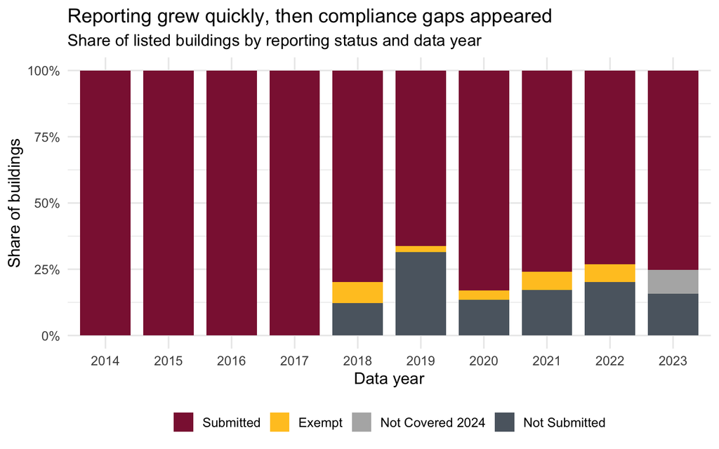

Figure 1: Reporting status of buildings by year

```r
energy %>%
  count(year, status) %>%
  group_by(year) %>% mutate(share = n / sum(n)) %>% ungroup() %>%
  mutate(status = factor(status, levels = c("Submitted", "Exempt",
                                            "Not Covered 2024", "Not Submitted"))) %>%
  ggplot(aes(factor(year), share, fill = status)) +
  geom_col(width = 0.8) +
  scale_y_continuous(labels = percent) +
  scale_fill_manual(values = c("Submitted" = asu_maroon, "Exempt" = asu_gold,
                               "Not Covered 2024" = "grey70",
                               "Not Submitted" = grey_dark), name = NULL) +
  labs(title = "Reporting grew quickly, then compliance gaps appeared",
       subtitle = "Share of listed buildings by reporting status and data year",
       x = "Data year", y = "Share of buildings") +
  theme_minimal(base_size = 13) + theme(legend.position = "bottom")
```

**What to notice:** In the first years, every record in the file is a submitted report. From 2018 on, the file also lists buildings that were exempt or **did not submit** at all (the gray and dark bars). This matters for a fair analysis because the buildings that report are not necessarily representative of all buildings. The 2014 and 2015 years also cover far fewer buildings, since the program was still ramping up, so I will treat those two years with caution.

## 2.5 Building the analysis dataset

I now create the dataset used for all efficiency questions. Each filter has a reason, and I count how many rows each step removes.

```r
analysis <- energy %>%
  filter(status == "Submitted",
         !is.na(site_eui), site_eui > 0, site_eui <= 500,
         !is.na(gfa), gfa > 0)

steps <- tibble(
  step = c("All rows in the file",
           "Keep only submitted reports",
           "...with a recorded EUI",
           "...with EUI between 0 and 500",
           "...with a known floor area (final analysis set)"),
  rows = c(nrow(energy),
           sum(energy$status == "Submitted"),
           sum(energy$status == "Submitted" & !is.na(energy$site_eui)),
           sum(energy$status == "Submitted" & !is.na(energy$site_eui) &
                 energy$site_eui > 0 & energy$site_eui <= 500),
           nrow(analysis))
)
steps %>% mutate(rows = comma(rows)) %>% kable(caption = "Rows remaining after each cleaning step")
```

Rows remaining after each cleaning step

| step | rows |
| --- | --- |
| All rows in the file | 28,329 |
| Keep only submitted reports | 23,193 |
| …with a recorded EUI | 22,817 |
| …with EUI between 0 and 500 | 22,721 |
| …with a known floor area (final analysis set) | 22,544 |

```r
extreme <- energy %>% filter(status == "Submitted", site_eui > 500)
cat("Submitted records with EUI above 500:", nrow(extreme), "\n")
```

```
## Submitted records with EUI above 500: 96
```

```r
cat("Largest EUI value in the file:", comma(max(energy$site_eui, na.rm = TRUE)), "kBtu/sq ft\n")
```

```
## Largest EUI value in the file: 15,634 kBtu/sq ft
```

```r
cat("Median EUI of the analysis set:", round(median(analysis$site_eui), 1), "kBtu/sq ft\n")
```

```
## Median EUI of the analysis set: 78.2 kBtu/sq ft
```

**Why 500?** Typical large buildings in this data use roughly 60 to 100 kBtu per square foot. A value above 500 usually reflects a data-entry error, a tiny floor area reported incorrectly, or an unusual facility such as a data center. These records are a very small fraction of the data, but because one 15,000-unit value can drag an average far from reality, removing them makes every comparison more trustworthy. I use **medians** throughout so that the analysis is robust even to the extremes that remain.

## 2.6 A first look at the distribution

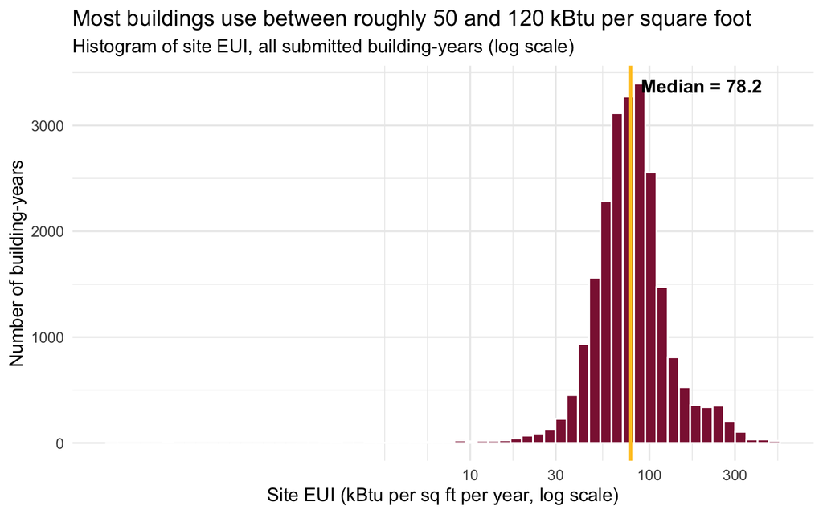

Figure 2: Distribution of site EUI (log scale)

```r
ggplot(analysis, aes(site_eui)) +
  geom_histogram(bins = 60, fill = asu_maroon, colour = "white") +
  geom_vline(xintercept = median(analysis$site_eui), colour = asu_gold,
             linewidth = 1.3) +
  annotate("text", x = median(analysis$site_eui) * 1.15, y = Inf,
           label = paste0("Median = ", round(median(analysis$site_eui), 1)),
           vjust = 2, hjust = 0, fontface = "bold") +
  scale_x_log10(breaks = c(10, 30, 100, 300)) +
  labs(title = "Most buildings use between roughly 50 and 120 kBtu per square foot",
       subtitle = "Histogram of site EUI, all submitted building-years (log scale)",
       x = "Site EUI (kBtu per sq ft per year, log scale)", y = "Number of building-years") +
  theme_minimal(base_size = 13)
```

**What to notice:** The distribution is **right-skewed**: most buildings cluster around the median, but a long tail of energy-hungry buildings stretches toward the right. I use a logarithmic axis so that the tail does not squash the main body. The skew is the reason I use medians instead of means in this project.

# 3. Exploratory Data Analysis

## 3.1 Question 1: Are Chicago’s buildings really getting more efficient?

**Why this is not obvious:** A falling average could be caused by several things that are *not* real improvement: a mild year, a pandemic, or a different set of buildings reporting each year. To separate real progress from illusion, I do two checks. First I look at the yearly trend, with and without weather adjustment. Then I follow **the same buildings** from 2016 to 2023.

### Step 1: the yearly trend

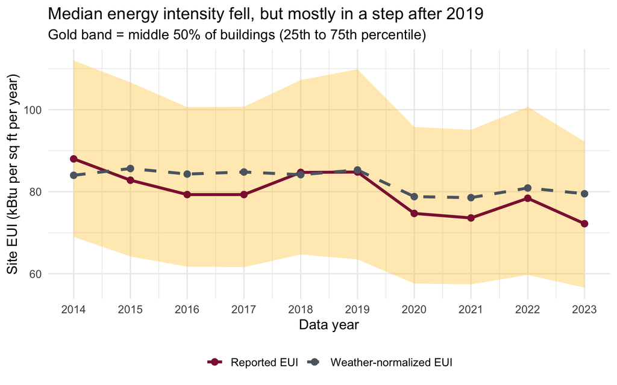

Figure 3: Median site EUI by year

```r
trend_long <- yearly %>%
  select(year, `Reported EUI` = median_eui, `Weather-normalized EUI` = median_wn) %>%
  pivot_longer(-year, names_to = "measure", values_to = "eui")

ggplot() +
  geom_ribbon(data = yearly, aes(year, ymin = q1, ymax = q3),
              fill = asu_gold, alpha = 0.35) +
  geom_line(data = trend_long, aes(year, eui, colour = measure, linetype = measure),
            linewidth = 1.3) +
  geom_point(data = trend_long, aes(year, eui, colour = measure), size = 2.5) +
  scale_colour_manual(values = c("Reported EUI" = asu_maroon,
                                 "Weather-normalized EUI" = grey_dark), name = NULL) +
  scale_linetype_manual(values = c("Reported EUI" = "solid",
                                   "Weather-normalized EUI" = "dashed"), name = NULL) +
  scale_x_continuous(breaks = 2014:2023) +
  labs(title = "Median energy intensity fell, but mostly in a step after 2019",
       subtitle = "Gold band = middle 50% of buildings (25th to 75th percentile)",
       x = "Data year", y = "Site EUI (kBtu per sq ft per year)") +
  theme_minimal(base_size = 13) + theme(legend.position = "bottom")
```

**Evidence:** The reported median EUI was about 84.7 in 2018 and 72.2 in 2023, a drop of roughly 15%. The weather-normalized line (dashed) fell by less, from about 85.3 in 2019 to 79.5 in 2023 (roughly 7%), so **part** of the reported drop reflects weather and part reflects a genuine change in how much energy buildings need. But look at the *shape*: the line is fairly flat from 2015 to 2019 and then **drops sharply in 2020**, the first pandemic year, instead of declining steadily. A steady retrofit-driven improvement would look like a smooth slope. A step down at 2020 suggests the pandemic had something to do with it.

### Step 2: following the same buildings

The yearly medians compare *different* groups of buildings each year. Buildings that appear in both 2016 and 2023 give a cleaner test, because the building mix cannot change.

```r
panel <- analysis %>%
  filter(year %in% c(2016, 2023)) %>%
  select(id, year, site_eui) %>%
  group_by(id, year) %>% slice(1) %>% ungroup() %>%
  pivot_wider(id_cols = id, names_from = year, values_from = site_eui,
              names_prefix = "eui_") %>%
  drop_na(eui_2016, eui_2023) %>%
  mutate(change = eui_2023 - eui_2016,
         pct_change = change / eui_2016,
         improved = change < 0)

panel_n <- nrow(panel)
panel_med <- median(panel$change)
panel_pct <- mean(panel$improved)
```

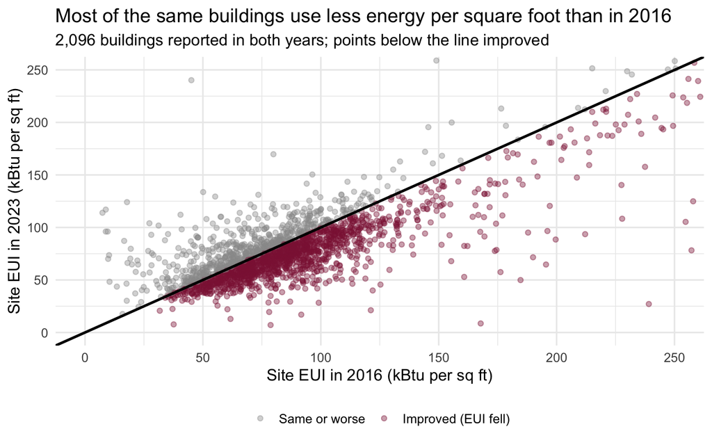

Figure 4: Same buildings, 2016 vs. 2023

```r
ggplot(panel, aes(eui_2016, eui_2023, colour = improved)) +
  geom_point(alpha = 0.4, size = 1.6) +
  geom_abline(slope = 1, intercept = 0, linewidth = 1, colour = "black") +
  scale_colour_manual(values = c("TRUE" = asu_maroon, "FALSE" = "grey60"),
                      labels = c("TRUE" = "Improved (EUI fell)", "FALSE" = "Same or worse"),
                      name = NULL) +
  coord_cartesian(xlim = c(0, 250), ylim = c(0, 250)) +
  labs(title = "Most of the same buildings use less energy per square foot than in 2016",
       subtitle = paste0(comma(panel_n), " buildings reported in both years; points below the line improved"),
       x = "Site EUI in 2016 (kBtu per sq ft)", y = "Site EUI in 2023 (kBtu per sq ft)") +
  theme_minimal(base_size = 13) + theme(legend.position = "bottom")
```

**Evidence:** Among the 2,096 buildings that reported in both years, the **median change was -6.8 kBtu per square foot**, and 68% of them improved. So the improvement is **real at the building level** and not just a statistical artifact of who reports. Still, the pandemic reduced occupancy and that may have helped many of these buildings, so I cannot attribute the whole gain to efficiency upgrades. This leads directly to Question 3.

**Answer to Question 1:** Yes, but with caveats. The improvement is real for the same buildings over time, yet a good share of the headline drop comes from the pandemic year and from weather.

### Step 3: emissions fell even faster

```r
ghgi_2019 <- get_y("median_ghgi", 2019)
ghgi_2023 <- get_y("median_ghgi", 2023)
eui_2019  <- get_y("median_eui", 2019)
eui_2023  <- get_y("median_eui", 2023)
tibble(
  measure = c("Median site EUI", "Median GHG intensity (kg CO2e/sq ft)"),
  `2019` = round(c(eui_2019, ghgi_2019), 2),
  `2023` = round(c(eui_2023, ghgi_2023), 2),
  `Change` = percent(c(eui_2023 / eui_2019 - 1, ghgi_2023 / ghgi_2019 - 1), accuracy = 0.1)
) %>% kable(caption = "Energy intensity vs. emissions intensity, 2019 to 2023")
```

Energy intensity vs. emissions intensity, 2019 to 2023

| measure | 2019 | 2023 | Change |
| --- | --- | --- | --- |
| Median site EUI | 84.8 | 72.2 | -14.9% |
| Median GHG intensity (kg CO2e/sq ft) | 8.0 | 6.2 | -22.5% |

**Interpretation:** Greenhouse gas intensity fell by a larger percentage than energy intensity. That is a non-obvious result: it means buildings are cutting emissions *faster than they are cutting energy use*. A likely explanation is that **the electricity grid itself got cleaner**, as the Midwest retired coal plants and added wind and nuclear power, so the same kilowatt-hour now causes fewer emissions. Part of the emissions progress, then, is not something building owners did. (I cannot test this directly with this dataset, since it has no grid-emissions variable, so I treat it as an informed hypothesis.)

## 3.2 Question 2: Do older buildings really use more energy?

**Why this is not obvious:** Common sense says that old buildings leak heat and waste energy, so energy use per square foot should rise with age. Let’s check.

```r
cor_age  <- cor(analysis$site_eui, analysis$year_built, use = "complete.obs", method = "spearman")
cor_size <- cor(analysis$site_eui, analysis$gfa, use = "complete.obs", method = "spearman")

era_summary <- analysis %>%
  filter(!is.na(era)) %>%
  group_by(era) %>%
  summarise(buildings = n(),
            median_eui = round(median(site_eui), 1),
            median_gas_share = percent(median(gas_share, na.rm = TRUE), accuracy = 1),
            .groups = "drop")

cat("Spearman correlation, EUI vs. year built:", round(cor_age, 3), "\n")
```

```
## Spearman correlation, EUI vs. year built: -0.016
```

```r
cat("Spearman correlation, EUI vs. floor area:", round(cor_size, 3), "\n")
```

```
## Spearman correlation, EUI vs. floor area: -0.068
```

```r
era_summary %>% kable(caption = "Energy intensity by construction era")
```

Energy intensity by construction era

| era | buildings | median_eui | median_gas_share |
| --- | --- | --- | --- |
| 1900 & earlier | 910 | 72.5 | 65% |
| 1901-1945 | 6542 | 76.6 | 69% |
| 1946-1975 | 5275 | 86.3 | 72% |
| 1976-2000 | 4477 | 77.5 | 49% |
| After 2000 | 5334 | 74.0 | 54% |

```r
analysis %>%
  filter(!is.na(size_class)) %>%
  group_by(size_class) %>%
  summarise(building_years = n(), median_eui = round(median(site_eui), 1), .groups = "drop") %>%
  kable(caption = "Energy intensity by building size (quintiles of floor area)")
```

Energy intensity by building size (quintiles of floor area)

| size_class | building_years | median_eui |
| --- | --- | --- |
| Smallest 20% | 4117 | 82.9 |
| Small | 4332 | 79.2 |
| Medium | 4506 | 75.9 |
| Large | 4681 | 78.8 |
| Largest 20% | 4908 | 75.6 |

Bigger buildings are slightly more efficient per square foot, but the differences are small compared with the differences between property types. The rank correlation between year built and EUI is essentially **zero** (-0.016), and the correlation with building size is also negligible (-0.068). If age were a simple driver of waste, I would see a clear trend. But a correlation coefficient only captures *straight line* relationships. Let me look at the whole picture.

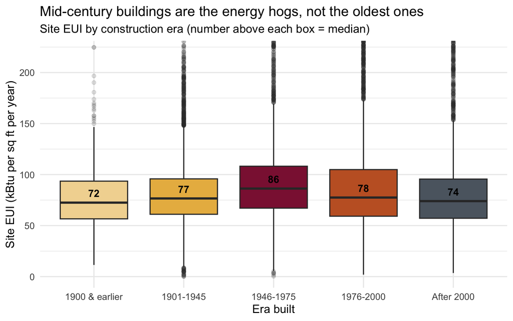

Figure 5: Energy intensity by construction era

```r
analysis %>%
  filter(!is.na(era)) %>%
  ggplot(aes(era, site_eui, fill = era)) +
  geom_boxplot(outlier.alpha = 0.15, show.legend = FALSE) +
  stat_summary(fun = median, geom = "text", aes(label = round(after_stat(y), 0)),
               vjust = -0.8, fontface = "bold", size = 4) +
  scale_fill_manual(values = c("#F2D7A0", "#E9B84F", asu_maroon, "#C4622D", grey_dark)) +
  coord_cartesian(ylim = c(0, 220)) +
  labs(title = "Mid-century buildings are the energy hogs, not the oldest ones",
       subtitle = "Site EUI by construction era (number above each box = median)",
       x = "Era built", y = "Site EUI (kBtu per sq ft per year)") +
  theme_minimal(base_size = 13)
```

**Evidence and interpretation:** The relationship is **U-shaped, not linear**. Buildings from **1946 to 1975** have the highest median EUI. The very oldest buildings (1900 and earlier) and buildings built after 2000 use *less* energy per square foot. Why would a 120-year-old building beat a 1960s one? A plausible explanation is that pre-war buildings often have thick masonry walls and small windows, and the ones that survive are typically well-maintained and have been renovated. Mid-century construction was built quickly and cheaply, with thin walls, single-pane glass, and little insulation, before modern energy codes existed. The post-2000 buildings benefit from those codes. This also suggests a policy implication: the 1946-1975 stock is the best target for retrofits.

**Answer to Question 2:** No, not in a simple way. Age on its own is a poor predictor. Mid-century buildings are the least efficient, and both the oldest and the newest buildings do better.

One more check: the age pattern could simply reflect different kinds of buildings in each era. Let me look within two major property types.

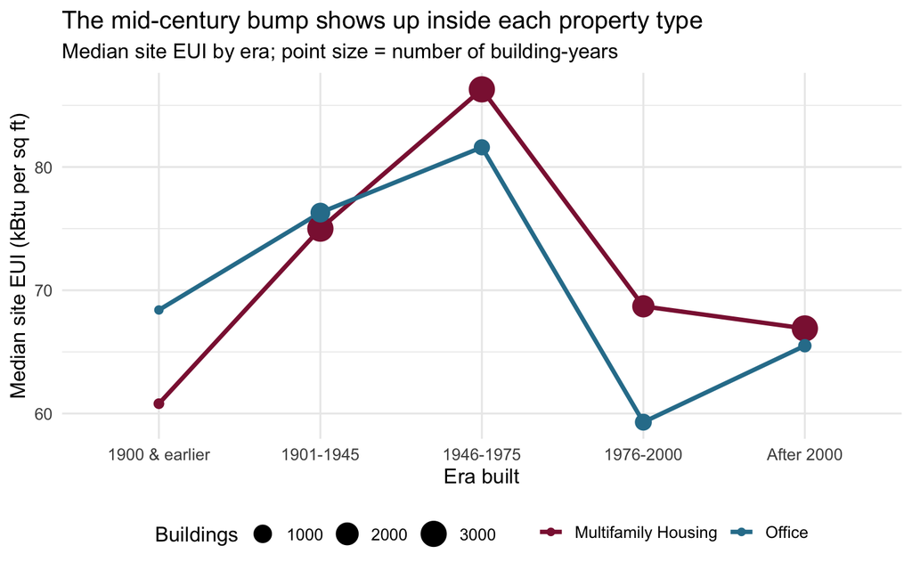

Figure 6: Age pattern within Multifamily and Office buildings

```r
analysis %>%
  filter(property_type %in% c("Multifamily Housing", "Office"), !is.na(era)) %>%
  group_by(property_type, era) %>%
  summarise(median_eui = median(site_eui), n = n(), .groups = "drop") %>%
  ggplot(aes(era, median_eui, colour = property_type, group = property_type)) +
  geom_line(linewidth = 1.3) +
  geom_point(aes(size = n)) +
  scale_colour_manual(values = c("Multifamily Housing" = asu_maroon, "Office" = "#2E7D9A"),
                      name = NULL) +
  scale_size_continuous(range = c(2, 7), name = "Buildings") +
  labs(title = "The mid-century bump shows up inside each property type",
       subtitle = "Median site EUI by era; point size = number of building-years",
       x = "Era built", y = "Median site EUI (kBtu per sq ft)") +
  theme_minimal(base_size = 13) + theme(legend.position = "bottom")
```

**What to notice:** For both multifamily housing and offices, the 1946-1975 group has the highest median, so the era effect is not simply an artifact of building mix. The point sizes are a reminder that the oldest eras contain far fewer observations, so those medians are less certain.

## 3.3 Question 3: Did COVID-19 change energy use differently for different buildings, and did it last?

**Why this is not obvious:** The pandemic emptied offices and hotels, so I expect their energy use to drop. The interesting question is whether things **went back to normal** afterwards, and whether the drop was the same everywhere.

To compare different property types fairly, I convert each type’s median EUI into an **index where 2019 = 100**. A value of 80 means 20% less energy per square foot than in 2019.

```r
major_types <- c("Office", "Hotel", "College/University", "Retail Store",
                 "K-12 School", "Multifamily Housing")

covid <- analysis %>%
  filter(property_type %in% major_types, year >= 2016) %>%
  group_by(property_type, year) %>%
  summarise(med = median(site_eui), n = n(), .groups = "drop") %>%
  group_by(property_type) %>%
  mutate(index = 100 * med / med[year == 2019]) %>%
  ungroup()

idx <- function(type, yr) round(covid$index[covid$property_type == type & covid$year == yr], 0)
```

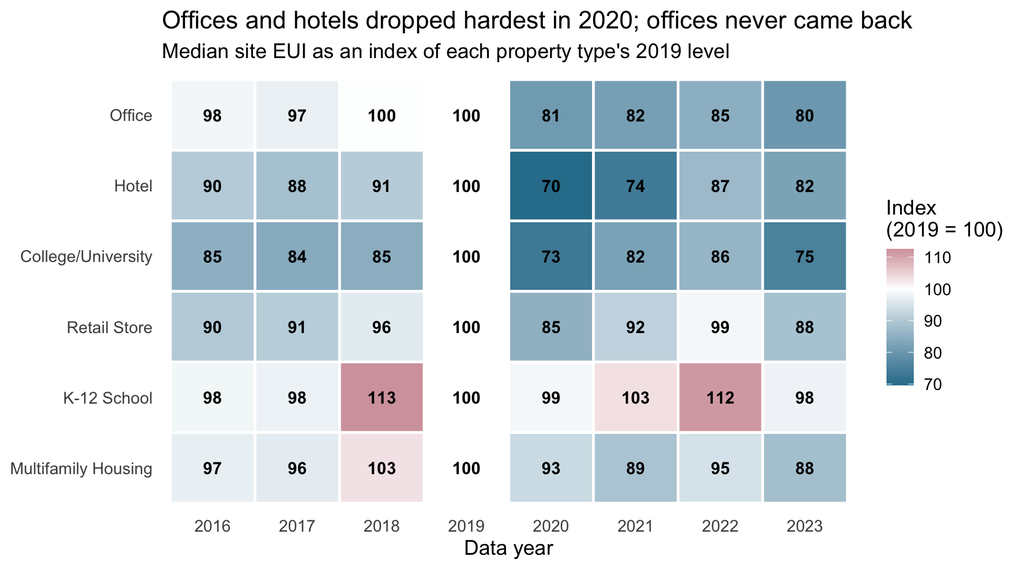

Figure 7: Energy intensity index by property type (2019 = 100)

```r
covid %>%
  mutate(property_type = factor(property_type,
                                levels = rev(c("Office", "Hotel", "College/University",
                                               "Retail Store", "K-12 School",
                                               "Multifamily Housing")))) %>%
  ggplot(aes(factor(year), property_type, fill = index)) +
  geom_tile(colour = "white", linewidth = 0.8) +
  geom_text(aes(label = round(index, 0)), size = 3.8, fontface = "bold") +
  scale_fill_gradient2(low = "#2E7D9A", mid = "white", high = asu_maroon,
                       midpoint = 100, name = "Index\n(2019 = 100)") +
  labs(title = "Offices and hotels dropped hardest in 2020; offices never came back",
       subtitle = "Median site EUI as an index of each property type's 2019 level",
       x = "Data year", y = NULL) +
  theme_minimal(base_size = 13) + theme(panel.grid = element_blank())
```

```r
analysis %>%
  filter(property_type %in% major_types) %>%
  group_by(property_type, period) %>%
  summarise(median_eui = round(median(site_eui), 1), .groups = "drop") %>%
  pivot_wider(names_from = period, values_from = median_eui) %>%
  kable(caption = "Median site EUI by property type and COVID period")
```

Median site EUI by property type and COVID period

| property_type | Before COVID | Pandemic years | After COVID |
| --- | --- | --- | --- |
| College/University | 92.9 | 82.6 | 83.0 |
| Hotel | 113.0 | 88.4 | 102.0 |
| K-12 School | 74.1 | 73.6 | 75.9 |
| Multifamily Housing | 77.5 | 71.2 | 71.4 |
| Office | 77.4 | 63.0 | 64.7 |
| Retail Store | 86.0 | 80.2 | 83.8 |

The table puts the heatmap into plain numbers: offices are far lower after COVID than before, while schools barely change.

**Answer to Question 3:** Yes. The pandemic affected property types very differently, and the change was lasting for offices but only partial for hotels.

This changes my reading of Question 1. A large part of the 2020 step down is tied to **how buildings are used**, not just how well they are built. A lower EUI in an empty office building is not necessarily a sign of better efficiency, and it is a reminder that EUI measures energy per square foot, not energy per person served.

## 3.4 Question 4: Which property types drive emissions, and what is the role of fuel?

**Why this is not obvious:** It would be natural to assume emissions are proportional to the number of buildings. But a hospital is not a house.

```r
latest <- analysis %>% filter(year == 2023, !is.na(ghg), ghg >= 0)

shares <- latest %>%
  group_by(property_type) %>%
  summarise(buildings = n(), floor_area = sum(gfa), emissions = sum(ghg),
            .groups = "drop") %>%
  mutate(across(c(buildings, floor_area, emissions), ~ .x / sum(.x))) %>%
  slice_max(emissions, n = 6)

shares_long <- shares %>%
  pivot_longer(-property_type, names_to = "measure", values_to = "share") %>%
  mutate(measure = factor(measure,
                          levels = c("buildings", "floor_area", "emissions"),
                          labels = c("Share of buildings", "Share of floor area",
                                     "Share of emissions")),
         property_type = fct_reorder(str_wrap(property_type, 18), share, .fun = max))

get_share <- function(type, col) shares[[col]][shares$property_type == type]
```

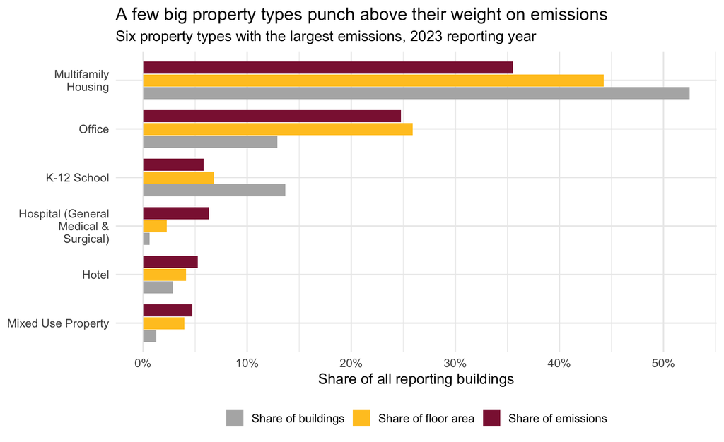

Figure 8: Buildings vs. floor area vs. emissions (2023)

```r
ggplot(shares_long, aes(property_type, share, fill = measure)) +
  geom_col(position = position_dodge(width = 0.8), width = 0.75) +
  coord_flip() +
  scale_y_continuous(labels = percent) +
  scale_fill_manual(values = c("Share of buildings" = "grey70",
                               "Share of floor area" = asu_gold,
                               "Share of emissions" = asu_maroon), name = NULL) +
  labs(title = "A few big property types punch above their weight on emissions",
       subtitle = "Six property types with the largest emissions, 2023 reporting year",
       x = NULL, y = "Share of all reporting buildings") +
  theme_minimal(base_size = 13) + theme(legend.position = "bottom")
```

**Evidence and interpretation:** Multifamily housing is about 52% of buildings in 2023 but only 36% of emissions. It is a *large count of relatively efficient, small emitters*. Offices are the reverse: about 13% of buildings but 25% of emissions, because they are physically large. The most striking case is **hospitals**: only 0.6% of buildings but about 6% of emissions. They run 24 hours a day with intensive ventilation and equipment. For a policymaker, this means that counting buildings is the wrong way to prioritize. A handful of hospitals matter as much as hundreds of apartment buildings.

### The role of fuel

Emissions depend on the *type* of energy, so I also check how much each building relies on natural gas.

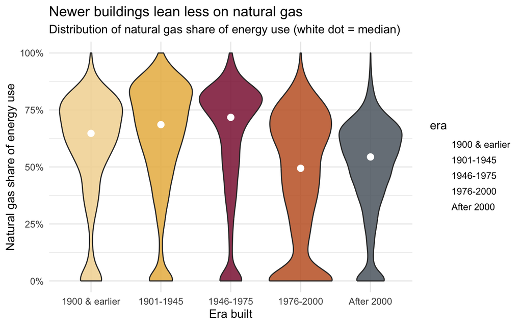

Figure 9: Natural gas share of energy use by construction era

```r
analysis %>%
  filter(!is.na(era), !is.na(gas_share)) %>%
  ggplot(aes(era, gas_share, fill = era)) +
  geom_violin(show.legend = FALSE, alpha = 0.85, scale = "width") +
  stat_summary(fun = median, geom = "point", colour = "white", size = 3) +
  scale_y_continuous(labels = percent) +
  scale_fill_manual(values = c("#F2D7A0", "#E9B84F", asu_maroon, "#C4622D", grey_dark)) +
  labs(title = "Newer buildings lean less on natural gas",
       subtitle = "Distribution of natural gas share of energy use (white dot = median)",
       x = "Era built", y = "Natural gas share of energy use") +
  theme_minimal(base_size = 13)
```

```r
analysis %>%
  filter(property_type %in% major_types, !is.na(gas_share)) %>%
  group_by(property_type) %>%
  summarise(median_gas_share = percent(median(gas_share), accuracy = 1),
            buildings = n(), .groups = "drop") %>%
  arrange(desc(median_gas_share)) %>%
  kable(caption = "Median natural gas share by property type")
```

Median natural gas share by property type

| property_type | median_gas_share | buildings |
| --- | --- | --- |
| Multifamily Housing | 70% | 11114 |
| K-12 School | 67% | 3101 |
| Hotel | 55% | 656 |
| College/University | 47% | 743 |
| Office | 33% | 3113 |
| Retail Store | 33% | 418 |

**What to notice:** The three eras up to 1975 sit highest, and buildings from after 1975 use a noticeably smaller share of natural gas. By property type, apartment buildings and schools run mostly on gas (they need lots of heat and hot water), while **offices are much more electric**. Since the grid is getting cleaner while gas is a fixed fossil fuel, buildings that depend on gas have less to gain from grid improvements, which is a strong argument for **electrification** of heating in older housing.

**Answer to Question 4:** Emissions are concentrated in a few large property types (offices, hospitals), while multifamily housing contributes far less than its share of buildings. Natural gas dependence is highest in older buildings, apartments, and schools.

## 3.5 Bonus: where in the city are the energy-hungry buildings?

Neighborhood comparisons are mostly a reflection of which property types are located there, but they are still interesting, especially for a data science portfolio. Because the data have coordinates, I can build an **interactive map**. Hover over a point to see the building’s details.

```r
map_df <- analysis %>%
  filter(year == 2023, !is.na(lat), !is.na(lon),
         lat > 41.6, lat < 42.1, lon > -88, lon < -87.5) %>%
  mutate(eui_capped = pmin(site_eui, 200),
         tip = paste0(coalesce(property_name, "Unnamed building"),
                      "<br>Type: ", property_type,
                      "<br>Site EUI: ", round(site_eui, 1),
                      "<br>Neighborhood: ", str_to_title(community_area)))

p_map <- ggplot(map_df, aes(lon, lat, colour = eui_capped, text = tip)) +
  geom_point(size = 1.4, alpha = 0.75) +
  scale_colour_viridis_c(option = "magma", direction = -1,
                         name = "Site EUI\n(capped at 200)") +
  coord_fixed(ratio = 1.3) +
  labs(title = "Chicago's large buildings by energy intensity (2023)",
       x = "Longitude", y = "Latitude") +
  theme_minimal(base_size = 12)

ggplotly(p_map, tooltip = "text")
```

[interactive chart not shown]

Figure 10 (interactive): Energy intensity of buildings across Chicago, 2023

**What to notice:** Each dot is a building, so the map traces the shape of the city: the dense downtown cluster (the Loop and the near north and west sides), the lakefront, and scattered buildings across the neighborhoods. Hover over any point to inspect that building. The chart below ranks neighborhoods by median EUI to make the geographic pattern easier to read.

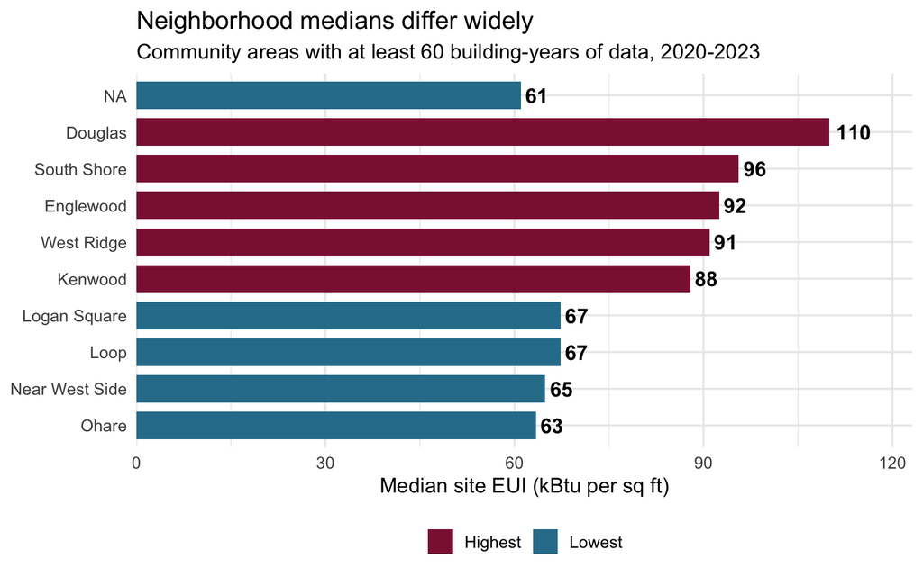

Figure 11: Neighborhoods with the lowest and highest median EUI

```r
hood <- analysis %>%
  filter(year >= 2020) %>%
  group_by(community_area) %>%
  summarise(n = n(), median_eui = median(site_eui), .groups = "drop") %>%
  filter(n >= 60)

bind_rows(slice_min(hood, median_eui, n = 5), slice_max(hood, median_eui, n = 5)) %>%
  mutate(group = if_else(median_eui <= median(hood$median_eui), "Lowest", "Highest"),
         area = fct_reorder(str_to_title(community_area), median_eui)) %>%
  ggplot(aes(area, median_eui, fill = group)) +
  geom_col(width = 0.75) +
  geom_text(aes(label = round(median_eui, 0)), hjust = -0.2, fontface = "bold") +
  coord_flip() +
  scale_fill_manual(values = c("Lowest" = "#2E7D9A", "Highest" = asu_maroon), name = NULL) +
  scale_y_continuous(expand = expansion(mult = c(0, 0.12))) +
  labs(title = "Neighborhood medians differ widely",
       subtitle = "Community areas with at least 60 building-years of data, 2020-2023",
       x = NULL, y = "Median site EUI (kBtu per sq ft)") +
  theme_minimal(base_size = 13) + theme(legend.position = "bottom")
```

The neighborhoods with the **lowest** median EUI include O’Hare, the Near West Side and the Loop, which have many offices and commercial buildings. The **highest** include several South Side community areas. I would expect this to reflect property type and age (offices are efficient per square foot, while older housing is not), but I did not test that here, and I do not claim that neighborhood *causes* the difference. It does, however, raise an equity question worth future study: older housing in some communities may carry higher energy costs for the residents who live there.

## 3.6 Sanity check: do the efficiency ratings agree with EUI?

As a validation of the data (and a sanity check on my cleaning), I check that the city’s own ratings behave sensibly. Higher ratings should go with lower energy use.

```r
analysis %>%
  filter(!is.na(chicago_rating)) %>%
  group_by(`Chicago Energy Rating (stars)` = chicago_rating) %>%
  summarise(buildings = n(), `Median EUI` = round(median(site_eui), 1), .groups = "drop") %>%
  kable(caption = "Median EUI by Chicago Energy Rating")
```

Median EUI by Chicago Energy Rating

| Chicago Energy Rating (stars) | buildings | Median EUI |
| --- | --- | --- |
| 1.0 | 2462 | 112.2 |
| 1.5 | 827 | 95.6 |
| 2.0 | 1820 | 93.0 |
| 2.5 | 1292 | 83.8 |
| 3.0 | 1825 | 78.1 |
| 3.5 | 1679 | 70.6 |
| 4.0 | 5111 | 57.9 |

```r
cat("Correlation between ENERGY STAR score and site EUI:",
    round(cor(analysis$energy_star, analysis$site_eui, use = "complete.obs"), 2), "\n")
```

```
## Correlation between ENERGY STAR score and site EUI: -0.53
```

The pattern is clean and monotone: the more stars a building has, the lower its median EUI, and the ENERGY STAR score has a clear negative correlation with EUI. That tells me my cleaning did not break anything and that EUI is a meaningful measure of performance.

# 4. Final Conclusions

## 4.1 Answers to my research questions

- **Q1 - Progress:** Chicago’s large buildings really did become less energy intensive. The median site EUI went from about 84.7 in 2018 to 72.2 in 2023, and, more convincingly, 68% of the 2,096 buildings that reported in both 2016 and 2023 improved. The gain is not just an illusion created by changes in who reports. But it is not a smooth, steady trend either, because most of the decline arrives as a **step in 2020**, which points to the pandemic as a major contributor.
- **Q2 - Age:** Age alone does not predict energy waste. The overall correlation is nearly zero (-0.016) and the real pattern is U-shaped: buildings from **1946 to 1975** are the least efficient, while pre-war buildings and post-2000 buildings do better. The result holds inside multifamily and office buildings, so it is not just an artifact of building mix.
- **Q3 - COVID-19:** The pandemic hit property types very differently. Offices dropped to roughly 81 on a 2019 = 100 scale and were still at about 80 in 2023, a lasting change. Hotels fell to about 70 and then partly rebounded (to about 82). Schools hardly changed.
- **Q4 - Emissions:** Emissions are concentrated in a few property types. Offices produce roughly twice their share of buildings in emissions, and hospitals are a tiny share of buildings but a large share of emissions. Multifamily housing is the opposite: lots of buildings, comparatively smaller emissions per building.

## 4.2 What the patterns mean

- **Not every drop in energy use is an efficiency win.** An office that is half empty uses less energy per square foot, but it is not a better building. Policymakers who read EUI trends as proof that retrofits are working could be misled.
- **Cleaner emissions are partly a gift from the power grid.** Greenhouse gas intensity fell faster than energy intensity, which is consistent with a cleaner electricity supply. Building owners are getting credit for some changes they did not make.
- **Mid-century buildings are the best retrofit target.** The 1946-1975 group has the highest energy intensity in nearly every comparison and also the heaviest natural gas use. Programs that target these buildings are likely to produce the biggest savings per dollar.
- **Prioritize by emissions, not by building count.** A small number of large facilities, such as hospitals and big offices, account for a share of emissions far above their share of the building stock.
- **Electrification matters for housing.** Apartment buildings and schools rely mostly on natural gas, while offices are more electric. As the grid keeps getting cleaner, switching heating from gas to electricity becomes one of the largest available levers, especially in older buildings.
- **The data themselves tell a story about compliance.** Starting in 2018, a visible share of covered buildings did not submit or were exempt, so the picture of “Chicago’s buildings” is really a picture of *the buildings that reported*. Better enforcement would improve every conclusion above.
- **Cleaning was not busywork.** Merging two inconsistent status labels, fixing neighborhood capitalization, and removing a handful of absurd EUI values changed what the data could say. Without those steps, two whole years of data (2020 and 2022) would have disappeared and a few extreme values would have distorted every average.

## 4.3 Limitations

- **Selection bias:** Only buildings that report are included, and reporting rates changed over time. The improvement I measured may be different for non-reporting buildings.
- **Pandemic confounding:** Because the 2020 drop coincides with COVID, I cannot fully separate genuine efficiency from reduced use. A longer post-pandemic record would help.
- **Correlation, not causation:** I observe patterns by era, type, and neighborhood, but I cannot prove why they occur (for example, I do not have data on insulation, window types, or renovations).
- **EUI is not perfect:** It is energy per square foot, so it ignores how many people use the building and what it is used for. It also depends on how accurately owners report floor area.
- **Outlier handling is a judgment call:** I excluded EUI above 500. A different threshold would change the numbers slightly, though I used medians to reduce sensitivity.
- **Small groups:** Some eras and property types have few observations, so their medians are less certain (visible as small points in Figure 6).
- **Grid explanation is a hypothesis:** The data contain no information about the electricity supply, so my explanation for faster emissions declines is informed speculation.

## 4.4 Possible explanations and ideas for future work

- **Test the grid hypothesis:** Add regional grid emissions factors by year and calculate emissions *as if* the grid had stayed the same, to see how much of the emissions decline buildings are responsible for.
- **Model the drivers of EUI:** Build a regression (or a random forest) with property type, era, size, fuel mix, and neighborhood to see which factors matter most after controlling for the others.
- **Follow the pandemic more carefully:** Compare the same buildings in 2019, 2020, and 2023 within each property type, and test whether offices that had higher pre-pandemic occupancy fell further.
- **Add equity data:** Join neighborhood income or demographic data to see whether less efficient housing is concentrated in lower-income areas.
- **Study compliance:** Investigate which buildings stop reporting, and whether they are systematically larger, older, or less efficient than those that report.
- **Evaluate retrofit programs:** If upgrade records are available, compare buildings that received retrofits with similar buildings that did not.

*Thanks for reading! If you ever find yourself in a half-empty Loop office building in January, remember: it is still heated, and it still shows up in the data.*